# STA 207 Final Project

Yutian Yang

2/27/2022

# Abstract

The COVID-19 project is targeting on studying the effect of region and vaccination policy on the death rate of COVID-19. In this data analysis project, the data sets are from the WHO website and Our World in Data website. After organizing the data, it contains 6649 observation and 9 variables. We then conduct the descriptive analysis on the data to gain some general and basic understanding of the data set. After the descriptive analysis, we then conduct the inferential analysis to study our question of interests. Then, in the discussion part, we conclude the result of our analysis and seek possible improvement in our future study.

# Introduction

The WHO dataset contains confirmed COVID-19 cases (new and cumulative) and deaths (new and cumulative) information from Jan 3rd 2020 to Feb 17th, 2022 across 236 contries globally. The Our World in Data dataset contains the vaccination policy information across 186 countries from Jan 1st, 2020 to Feb 17th, 2022. In this project, To minimize other potential factors such as Season and Economics that can effect the analysis, I have limited the choice of countries in the Northern Hemisphere. Then, I choose one to two countries that have the top GDP within each of the region (except “Others”region). In this case, countries should experience similar seasons and economics.

In this project, the primary questions of interest is to find

- whether there is any differences in death_rates among countries across regions.
- whether there is any differences in death_rates among countries across vaccination policy.
- whether there is any interaction effect in death_rates among countries across regions and vaccination policy. In particular, we will treat countries with dates (a country with a specific date is unique) as an observation.

The original WHO dataset contains 184149 observations and 8 variables. The original Our World in Data dataset contains 142551 observations and 4 variables. However, since the countries name have some minor differences in the two dataset, I then modified the names of the 9 chosen countries. I then join the two datasets together to merge the information into one data frame. After that, I calculate death rate by dividing cumulative deaths over cumulative cases. Finally, after filtering the chosen countries, I removed non-essential data: when there is no vaccination policy and no cumulative cases and no new deaths since they will have no impact on the following analysis process. The new data set has 6649 observations and 9 variables.

The two predictor variable in this project are Region and Vaccination Policy. Region contains following levels:

- “AFRO”: Africa
- “AMRO”: Americas
- “EMRO”: Eastern Mediterranean
- “EURO”: Europe
- “SEARO”: South-East Asia
- “WPRO”: Western Pacific

Vaccination Policy is also a categorical variable that contains the strictness of vaccination policy with a country. It is measured from:

- Level 0: No Policy
- Level 1: Vaccination required with only one group
- Level 2: Vaccination required with only two groups
- Level 3: Vaccination required with all vulnerable group
- Level 4: Vaccination required with vulnerable group + some others
- Level 5: Vaccination universally required

# Background

In this project, we will study the dataset from the World Health Organization (WHO) and Our World in Data website. Coronavirus disease 2019 (COVID-19) is a contagious disease caused by severe acute respiratory syndrome coronavirus 2 (SARS-CoV-2). The first known case was identified in Wuhan, China, in December 2019. The disease has then widely spread , whcih has been causing an ongoing worldwide pandemic.

The World Health Organization (WHO) declared COVID-19 as a Public Health Emergency of International Concern on 30 January 2020 and a pandemic on 11 March 2020. As of today (March 3rd, 2022), the COVID-19 pandemic had caused more than 5.97 million deaths globally, making it one of the deadliest disease in history.

# Descriptive Analysis

```
##    Min. 1st Qu.  Median    Mean 3rd Qu.    Max.
##   0.000   1.619   2.796   3.987   5.499  17.169
```

```
## [1] "AFRO"  "AMRO"  "EMRO"  "EURO"  "SEARO" "WPRO"
```

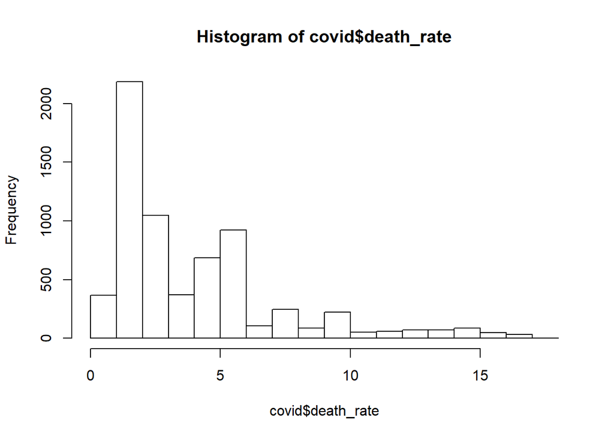

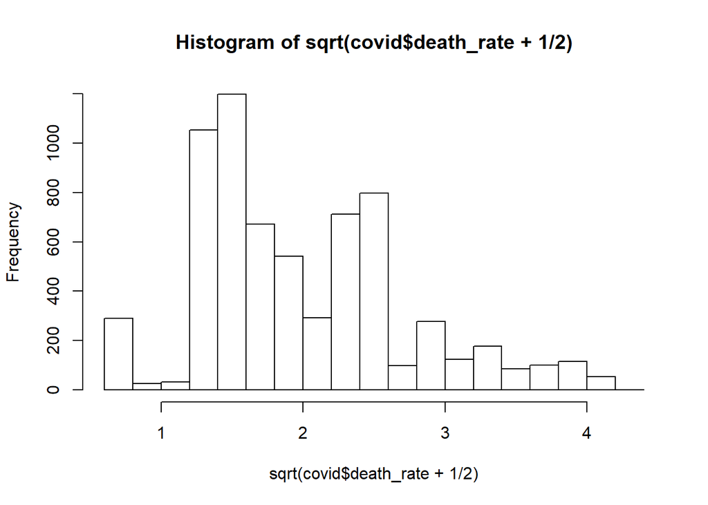

From the summary statistics and the two histograms above, We can see the median of the death rate is 2.796, but the mean of the death rate is 3.987, which is far apart from the median. This indicates that the response variable is heavily right skewed, which may violate the assumptions of ANOVA, thus we will proceed the data with some transformation.

Since our response variable is “death rate”, we will not be able to apply log transformation, because it will result negative infinity for observations that have a death rate of 0, so we will proceed with poisson transformation. After poisson transformation, the histogram suggests that the distribution of the response variable death rate has been more normal.

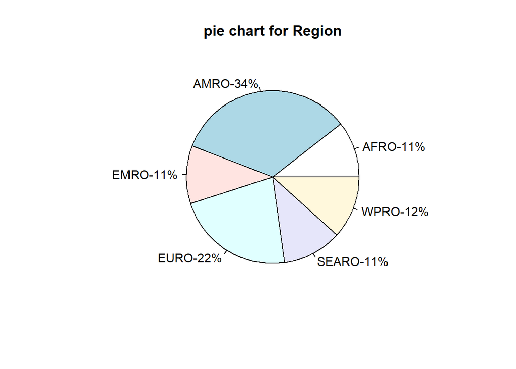

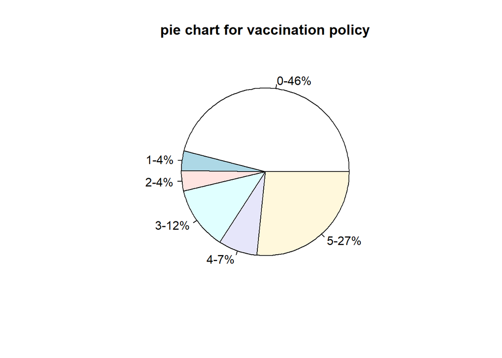

From the The two pie plots above, we can observe that the weights of treatment levels in the dataset are not balanced. Continuing with ANOVA that uses Type I Sum of Squares will possibly not satisfy the assumptions of ANOVA. Therefore, ANOVA with Type II Sum of Squares need to be considered in the later inferential analysis part since we will not consider the interaction effect between Region and Vaccination Policy.

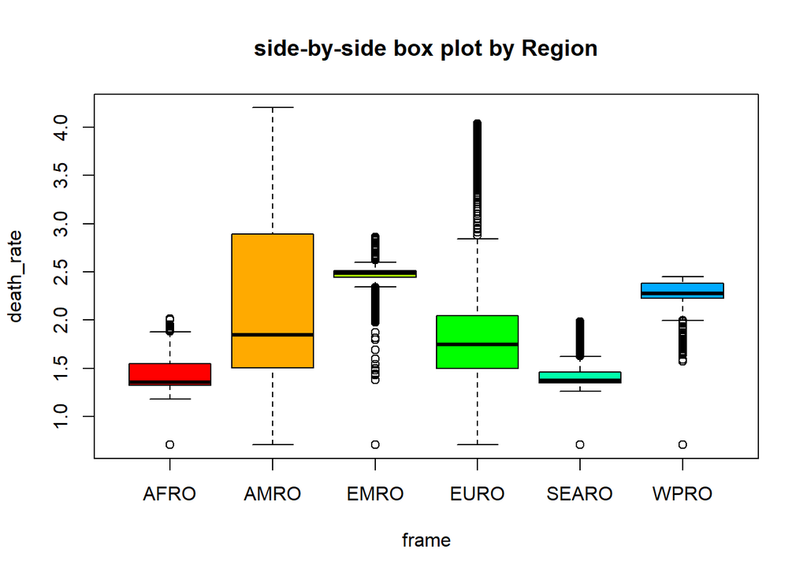

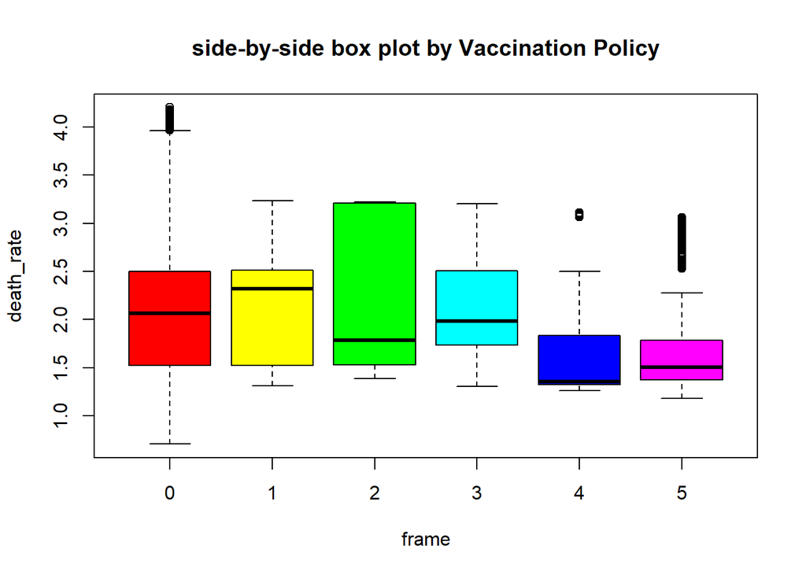

From the box plots above, we can notice there are obvious differences in the mean of death rate (after poisson transformation) among different regions, but the differences in the mean of death rate among different vaccination policy is not too clear.

# Inferential Analysis

From the two pie plots above, we can observe that the weights of treatment levels in the dataset are not balanced. Continue with ANOVA that uses Type I Sum of Squares will possibly not satisfy the assumptions of ANOVA. Therefore, ANOVA with Type II Sum of Squares need to be considered in the later inferential analysis part since we will not consider the interaction effect between Region and Vaccination Policy.

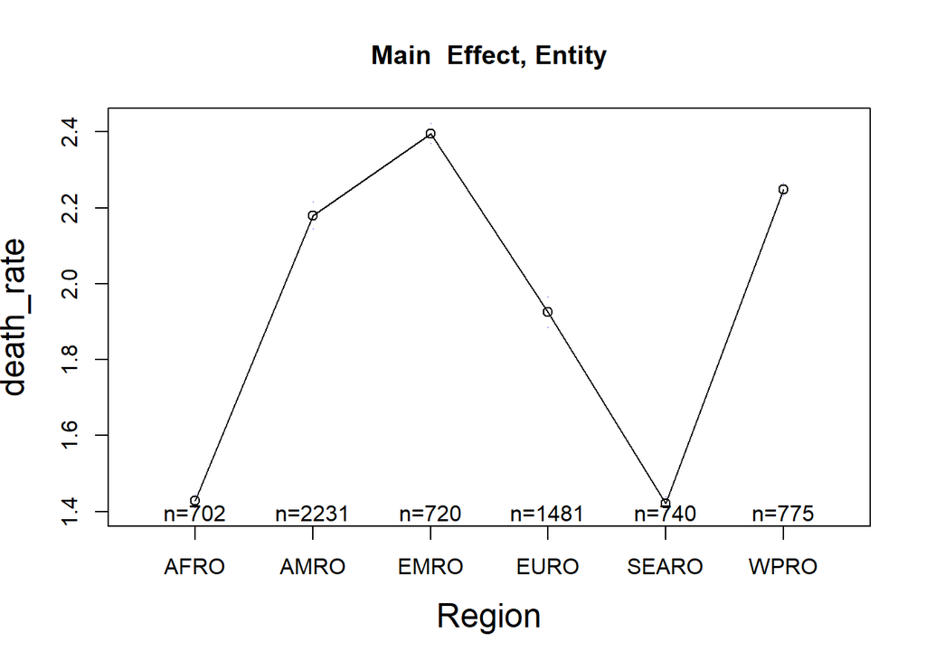

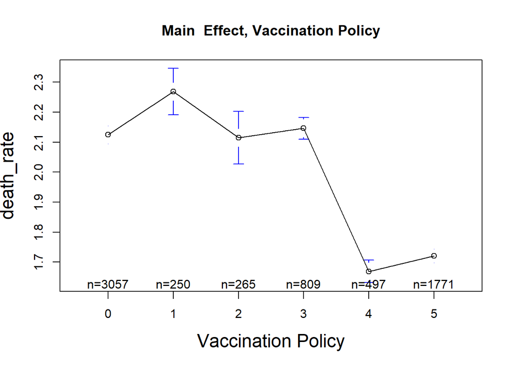

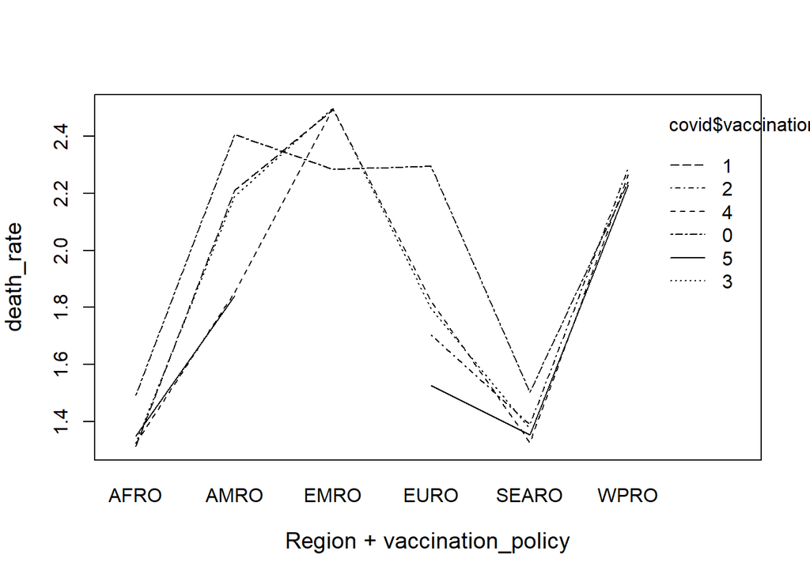

Both the main effect plots of “Region” and “Vaccination Policy” indicate some strong difference in the death rate among observations, so we will include both predictor for the following modeling and analyzation.

The interaction plot does not show strong enough interaction. Besides, some regions have decided to skip a few vaccination policy level. For example, the Europe region has jumped their vaccination policy from level 0 to level 2. It results some vaccination policy levels missing for certain regions, and it will cause the interaction model return NA for some coefficients, which hinders the Type III ANOVA analysis later. Therefore, we do not consider interaction effect in this analysis.

Thus, We define the two-way ANOVA model as follows $Y_{ijk} = \mu_{..} + \alpha_{i} + \beta_{j} + \epsilon_{ijk}$, where the index $\alpha_{i}$ represents the Region, and the index $\beta_{j}$ represents the Vaccination Policy. $\mu_{..}$ is the true average death rate (after poisson transformation) across all treatment groups (Region and Vaccination Policy). $\epsilon_{ijk}$ is the error term.

The constraints of the model is as below:

$\sum \alpha_i = \sum \beta_j = 0$

For this ANOVA model, the assumptions are as below:

1. Normality: $\epsilon_{ijk}$ follows a normal distribution;
2. Error term $\epsilon_{ijk}$ are independent with each other;
3. No multicollinearity among predictor variables (Region, Vaccination Policy);
4. Constant variance among data.

Then we want to explore

$H_0: \alpha_i = 0\ for\ all\ i$ vs. $H_1: not\ all\ \alpha_i = 0$

$H_0: \beta_i = 0\ for\ all\ i$ vs. $H_1: not\ all\ \beta_i = 0$

at 95% significance level.

## Approach I: Type II ANOVA

```
## Anova Table (Type II tests)
##
## Response: poi_deaths_rate
##                     Sum Sq   Df F value    Pr(>F)
## WHO_region          654.20    5  339.90 < 2.2e-16 ***
## vaccination_policy  212.97    5  110.65 < 2.2e-16 ***
## Residuals          2555.19 6638
## ---
## Signif. codes:  0 '***' 0.001 '**' 0.01 '*' 0.05 '.' 0.1 ' ' 1
```

- there is significant difference in the average death rate of different region;
- and there is significant difference in the average death rate of different vaccination policy.

## Approach II: Tukey-Krama test

To have more detailed pairwise comparison, I decided to use Tukey-Krama test to construct 95% confidence interval on both of the $H_0$ (null hypothesis).

```
##                    diff          lwr         upr        p.adj
## AMRO-AFRO   0.752524791  0.675990180  0.82905940 1.552425e-12
## EMRO-AFRO   0.968202340  0.874395355  1.06200933 1.552425e-12
## EURO-AFRO   0.497263617  0.416223330  0.57830390 1.552425e-12
## SEARO-AFRO -0.006357047 -0.099536123  0.08682203 9.999618e-01
## WPRO-AFRO   0.821469101  0.729320016  0.91361819 1.552425e-12
## EMRO-AMRO   0.215677550  0.139874137  0.29148096 1.635470e-12
## EURO-AMRO  -0.255261174 -0.314539626 -0.19598272 1.552425e-12
## SEARO-AMRO -0.758881837 -0.833906813 -0.68385686 1.552425e-12
## WPRO-AMRO   0.068944310 -0.004797541  0.14268616 8.249295e-02
## EURO-EMRO  -0.470938723 -0.551288825 -0.39058862 1.552425e-12
## SEARO-EMRO -0.974559387 -1.067138818 -0.88197996 1.552425e-12
## WPRO-EMRO  -0.146733240 -0.238275932 -0.05519055 7.302294e-05
## SEARO-EURO -0.503620664 -0.583236796 -0.42400453 1.552425e-12
## WPRO-EURO   0.324205484  0.245797307  0.40261366 1.552425e-12
## WPRO-SEARO  0.827826147  0.736927004  0.91872529 1.552425e-12
```

```
##                  diff        lwr         upr        p.adj
## AMRO-AFRO   0.7525248  0.6759902  0.82905940 1.552425e-12
## EMRO-AFRO   0.9682023  0.8743954  1.06200933 1.552425e-12
## EURO-AFRO   0.4972636  0.4162233  0.57830390 1.552425e-12
## WPRO-AFRO   0.8214691  0.7293200  0.91361819 1.552425e-12
## EMRO-AMRO   0.2156775  0.1398741  0.29148096 1.635470e-12
## EURO-AMRO  -0.2552612 -0.3145396 -0.19598272 1.552425e-12
## SEARO-AMRO -0.7588818 -0.8339068 -0.68385686 1.552425e-12
## EURO-EMRO  -0.4709387 -0.5512888 -0.39058862 1.552425e-12
## SEARO-EMRO -0.9745594 -1.0671388 -0.88197996 1.552425e-12
## WPRO-EMRO  -0.1467332 -0.2382759 -0.05519055 7.302294e-05
## SEARO-EURO -0.5036207 -0.5832368 -0.42400453 1.552425e-12
## WPRO-EURO   0.3242055  0.2457973  0.40261366 1.552425e-12
## WPRO-SEARO  0.8278261  0.7369270  0.91872529 1.552425e-12
```

```
##            diff        lwr          upr        p.adj
## 1-0 -0.10587668 -0.2222141  0.010460777 9.873625e-02
## 2-0 -0.04184625 -0.1550992  0.071406649 8.996337e-01
## 3-0 -0.14829729 -0.2182217 -0.078372824 2.352324e-08
## 4-0 -0.24840476 -0.3339416 -0.162867966 1.620704e-12
## 5-0 -0.42007589 -0.4728896 -0.367262160 1.552425e-12
## 2-1  0.06403042 -0.0919000  0.219960848 8.509696e-01
## 3-1 -0.04242061 -0.1703952  0.085554027 9.347672e-01
## 4-1 -0.14252809 -0.2796580 -0.005398145 3.616981e-02
## 5-1 -0.31419921 -0.4336871 -0.194711273 2.709277e-12
## 3-2 -0.10645103 -0.2316282  0.018726138 1.479967e-01
## 4-2 -0.20655851 -0.3410815 -0.072035511 1.773557e-04
## 5-2 -0.37822963 -0.4947165 -0.261742796 1.617484e-12
## 4-3 -0.10010748 -0.2009026  0.000687599 5.280218e-02
## 5-3 -0.27177860 -0.3468279 -0.196729327 1.608602e-12
## 5-4 -0.17167112 -0.2614459 -0.081896367 7.748525e-07
```

```
##           diff        lwr          upr        p.adj
## 3-0 -0.1482973 -0.2182217 -0.078372824 2.352324e-08
## 4-0 -0.2484048 -0.3339416 -0.162867966 1.620704e-12
## 5-0 -0.4200759 -0.4728896 -0.367262160 1.552425e-12
## 4-1 -0.1425281 -0.2796580 -0.005398145 3.616981e-02
## 5-1 -0.3141992 -0.4336871 -0.194711273 2.709277e-12
## 4-2 -0.2065585 -0.3410815 -0.072035511 1.773557e-04
## 5-2 -0.3782296 -0.4947165 -0.261742796 1.617484e-12
## 5-3 -0.2717786 -0.3468279 -0.196729327 1.608602e-12
## 5-4 -0.1716711 -0.2614459 -0.081896367 7.748525e-07
```

From the above Tukey-Krama test and 95% confidence interval on regions, the pairwise confidence interval:

- WPRO-AMRO contain 0, which suggest there are no significant difference of death rate between West Pacific and America;
- SEARO-AFRO contain 0, which suggest there are no significant difference of death rate between South East Asia and Africa. However, since not all confidence intervals contain 0, we can then reject the null hypothesis and conclude there is significant difference in death rate between some regions.

Since we have concluded that there is significant difference between death rate among region and vaccination policy, We then would like to know which combination of region and vaccination policy will have the highest and lowest death rate.

```
##              0        1        2        3        4        5
## AFRO  1.492817 1.312265       NA 1.322782 1.323463 1.347733
## AMRO  2.407326 2.209904 2.485624 2.189338 1.853512 1.841472
## EMRO  2.283868 2.492933       NA 2.499383 2.497798       NA
## EURO  2.295108       NA 1.703678 1.796399 1.822228 1.526285
## SEARO 1.502999       NA 1.389658 1.373121 1.324902 1.352483
## WPRO  2.241330 2.313584 2.289346       NA 2.264656 2.228932
```

```
##      row col
## EMRO   3   4
```

```
##      row col
## AFRO   1   2
```

# Sensitivity analysis

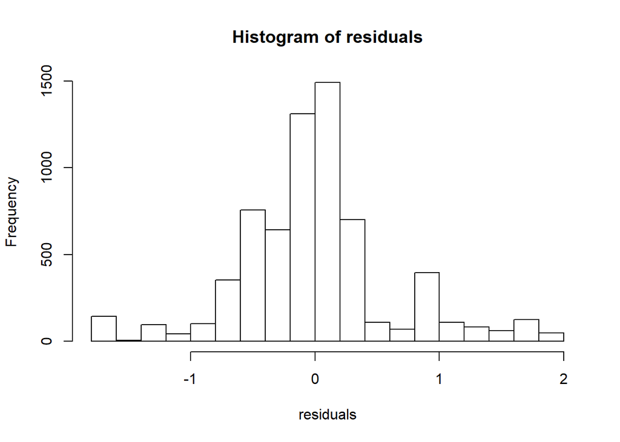

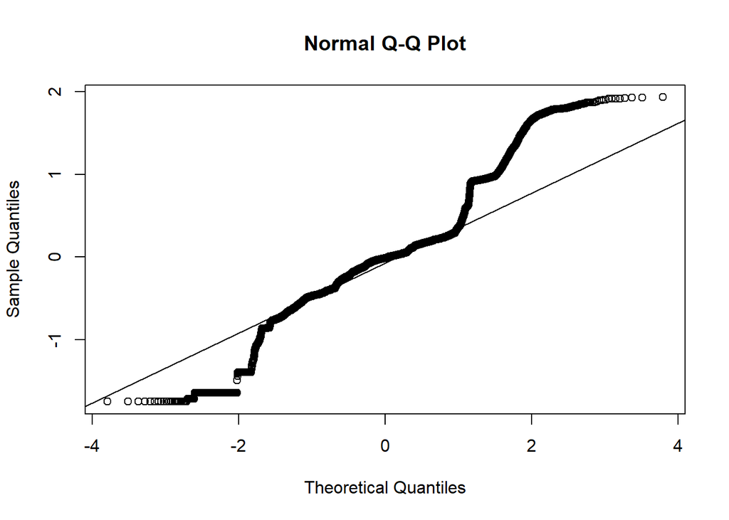

```
##
##  Anderson-Darling normality test
##
## data:  anova.fit.twoway$residuals
## A = 156.88, p-value < 2.2e-16
```

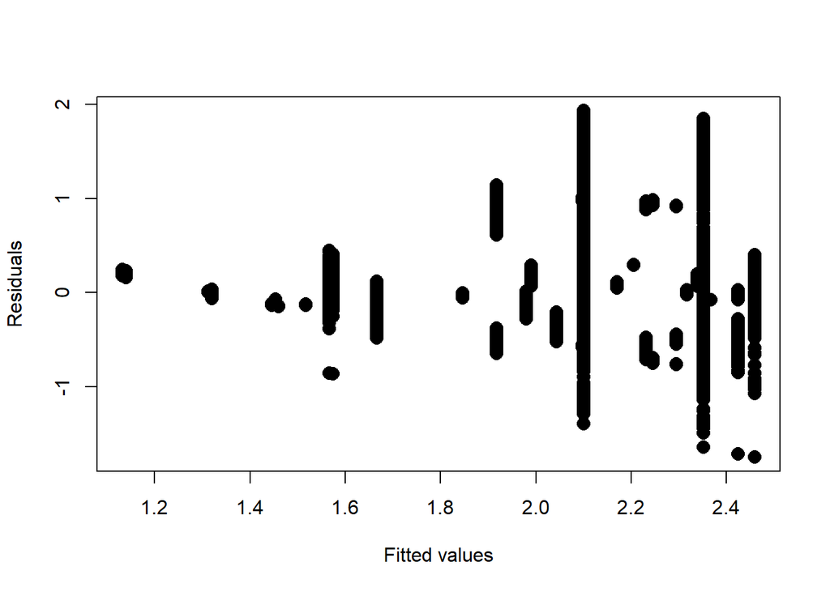

```
##  lag Autocorrelation D-W Statistic p-value
##    1       0.9943721    0.01004703       0
##  Alternative hypothesis: rho != 0
```

```
## Levene's Test for Homogeneity of Variance (center = median)
##         Df F value    Pr(>F)
## group    5  437.78 < 2.2e-16 ***
##       6643
## ---
## Signif. codes:  0 '***' 0.001 '**' 0.01 '*' 0.05 '.' 0.1 ' ' 1
```

```
## Levene's Test for Homogeneity of Variance (center = median)
##         Df F value    Pr(>F)
## group    5  138.58 < 2.2e-16 ***
##       6643
## ---
## Signif. codes:  0 '***' 0.001 '**' 0.01 '*' 0.05 '.' 0.1 ' ' 1
```

Looking at the histogram of the residuals of our ANOVA model, it is bell-shape, so the residuals are likely normally distributed. But from the residuals vs. fitted we do not observe constant variance. It also does not pass the Anderson-Darling normality test, Durbin Watson independent test, and Levene constant variance test since the p-values are less than 0.05 in all three tests, we reject the null hypothesis, which causes the failure of passing the test. Therefore, ANOVA assumptions are not satisfied.

```
##
##  Kruskal-Wallis rank sum test
##
## data:  death_rate by WHO_region
## Kruskal-Wallis chi-squared = 2129.1, df = 5, p-value < 2.2e-16
```

```
##
##  Kruskal-Wallis rank sum test
##
## data:  death_rate by vaccination_policy
## Kruskal-Wallis chi-squared = 777.53, df = 5, p-value < 2.2e-16
```

Then, we will need to introduce non-parametric test like Kruskal-Wallis rank sum test to validate our results in the parametric model. As the p-value is less than the significance level 0.05, we can conclude that there are significant differences between both treatment groups. In other words, there are significant differences in the true median of the death rate among both regions and levels of vaccination policies.

# Discussion

The original dataset is achieved from the WHO website and Our World in Data website. The WHO dataset contains the confirmed cases and deaths information of COVID-19 with 184149 observations and 8 variables. The Our World in Data dataset contains the vaccination policy information of COVID-19 with 142551 observations and 4 variables. Since we are only focusing on the northern hemisphere and relatively well developed countries to minize other confounding effects like season and economics, I filtered 9 countries from each continent (except Oceania and Antarctica). After that, I then join the two datasets together to merge the information into one data frame. To create the response variable for this analysis, I calculate death rate by dividing cumulative deaths over cumulative cases. Finally, I removed data whre there is no vaccination policy and no cumulative cases and no new deaths, because they do not impact the following analysis process. The new dataset has 6649 observations and 9 variables.

Then the descriptive analysis is conducted. From the pie plot of regions and vaccination policies, we can observe that the distribution of regions and vaccination policy is not balanced; thus, we will need consider Type II or Type III ANOVA for the following inferential analysis. The boxplot of region indicates that the average death rate across all regions are not the same. Similar conclusion can be drawn from the boxplot of vaccination policy.

I then apply inferential analysis to conduct further study to answer the question of interest. I first observe from the main effect and interaction effect plot and decide to use Type II two way ANOVA without interaction. By looking at the F value, I am able to conclude that both variables are significant, and Region is the most significant variable in the model since it has greater $F^*$ value. Therefore, we can reject the $H_0$ and conclude that there is significant difference in the average death rate of different region; and there is significant difference in the average death rate of different vaccination policy;

To find more details, I implemented Tukey’s range test to calculate 95% pairwise confidence interval among Regions and among vaccination policies. We then conclude the average death rate of some regions is significantly higher than the other, keeping the vaccination policy fixed. we then calculate 95% pairwise confidence interval among the vaccination policy. Similarly, we conclude the average death rate of different levels of vaccination policy are not same across all regions.

Then, we conduct the sensitivity analysis to check if our assumptions of the model is plausible. However, by observing from the diagnostic plots and running diagnostic tests, we are not able to conclude that the assumptions of our model are valid. Thus, I decide to use nonparametric test to justify my results. I then implemented Kruskal-Wallis rank sum test on both factors, and it suggests that there are significant differences in the true median of the death rate among both regions and levels of vaccination policies, as both p-values are less than the significance level 0.05. This way, our previous results are justified, and we are able to draw statistical significant conclusion from it.

Based on this study, policy maker should increase the levels of vaccination policy to decrease the average death rate within the region/country.

In the future, the research could also aim for studying other confounding factors that may significantly influence the death rate of COVID-19. Also, Many countries/regions have made the stringent vaccination policy but people decide to not obey, which can generate some deviation from the expected results. To be more strict, the level of vaccination policy is not randomly assigned to countries, but have a developing timeline in an increased pattern; therefore, some time series related analysis could be perform in order to achieve better results.

# Reference

1. https://www.scribbr.com/statistics/two-way-anova/
2. https://www.itl.nist.gov/div898/handbook/prc/section4/prc43.htm
3. https://rcompanion.org/handbook/G_09.html
4. https://www.ics.uci.edu/~jutts/110/Lecture18.pdf
5. https://rpubs.com/WhataBurger/Anovatype3
6. https://www.statology.org/droplevels-r/
7. http://www.sthda.com/english/wiki/kruskal-wallis-test-in-r
8. Anscombe, F. J. (1948). The Transformation of Poisson, Binomial and Negative-Binomial Data. Biometrika, 35(3/4), 246–254. https://doi.org/10.2307/2332343